# Interpolation Study

Error Distribution of Different Methods

Michael C. Rubin

11/17/2020

# INTRODUCTION

## Context

Precision Agriculture is on the rise. This requires that timely and precise information from the field are provided to the farmer, so he can take better decisions and apply input materials more precisely. Such information is typically soil or weather data, such as temperature, rain or soil PH. One of the big challenges is that these information from the (large) fields are very sparse. Many precision agriculture Startups have created platforms, which seek to solve this problem by using available data from sample points and ‘distribute’ them to a continuous space, i.e. the entire field. Therefore, the companies use different kinds of Geospatial interpolation techniques (henceforth Interpolation), which map values from data sample points to a continuous geographical. The final result is typically a heatmap, which claims to show the variables for each individual point in the x/y map. Given that the farmer will base potentially harmful decisions on such maps, there exists a justified concern of how exact and reliable are these information is. This leads to the questions of whether the interpolation techniques applied (which is just a mathematical formula) are doing a good job in estimating the values for the unknown locations. Unfortunately, most of the tools do not provide any in formation regarding uncertainty, which usually is part of a serious statistical estimation process.

## Objective & Research Questions

The at hand research intends to shed light onto the above-mentioned question. We will assess the quality of different interpolation algorithms in different settings and for different variables. Our goal is to provide concrete information regarding the quality, its behavior and contextualize this with Meteorological and Statistical techniques. Initially, we need to clarify and define few important points. Interpolation methods are estimations of unknown values. Hence, we will use the term estimation and estimator as a surrogate for the interpolation. Further, as every estimation, they are associated with estimation errors. These errors are the main interest of the at-hand study. We will answer the following questions:

- **Quality of Estimation**: How exact, precise and reliable are different interpolation methods
- **Context Dependency**: Does the exactness, precision and reliability depend on contexts
- **Error behavior**: Can we say anything about the errors behavior?
- **Probabilistic Assessment**: What probabilistic tools can we hire for assessing the uncertainty and errors?
- **Meteorological Assessment**: What meteorological tools can we hire for assessing the errors?
- **Mathematical Assessment**: Can we connect the behavior of errors to modern mathematical tools?

## Problem Statement & Set-Up

We are fortunate to have a large meteorological data set at our hand, which is the network of 2600 Agrometeorological Weather Station all over South America. We will use a selection of these data for the study.

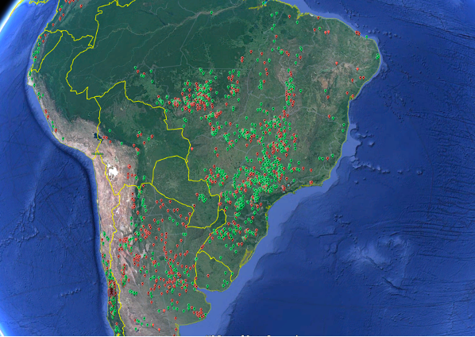

We select a number of so-called *interpollation regions* in such a way that we have at least 4 weather stations nearby. We purposefully vary the geographical area of such regions so to obtain a good idea of how distance relate to interpolation quality. Within each region, we choose the stations in a way so that we have always 3 or more stations at the edges of the region, which are the *neighbours*, and one station inside the region, which is denominated the *Point zero*. These neighbours represent our data sample points, from which we try to estimate the data for each point inside the region (this is the interpolaiton process). As we are interested in testing the accuracy of this interpolations, we then test the obtained values against the station at point zero. Important to say that we do not use the values from point zero station for the interpolation - it is only our verification data. Below a Schema of the Set-Up:

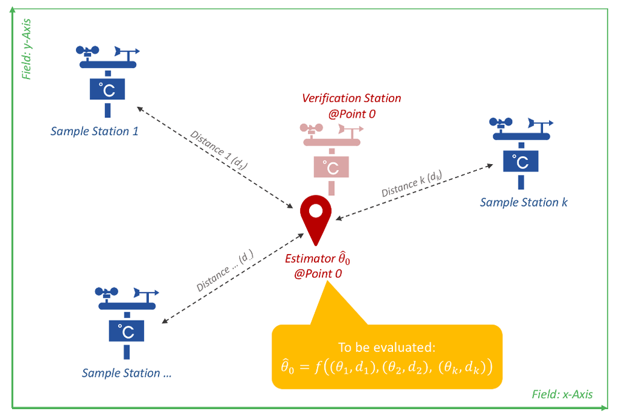

The Mathematical set-up here is:
$$\hat\theta_{0}
=f((\theta_{1},d_{1}),(\theta_{2},d_{2}),(\theta_{k},d_{k}))$$
Where we look for:
$$f(\theta,d)^{*}=min[{f((\theta_{1},d_{1}),(\theta_{2},d_{2}),(\theta_{k},d_{k}))}-\theta_{0}]$$
Where is the parameter to estimate (like temperature, rain) and d is the distance to the respective station. In simple words, what is on scrutiny here is f, the function of the parameter and the distance, which maps our sample data to the unknown estimator.

## Methodology

# CASE-BY-CASE WALK THROUGHS

## Case 1: Air Temperatures in Goias, Brazil

### Area & Setting

First, we set the stage:

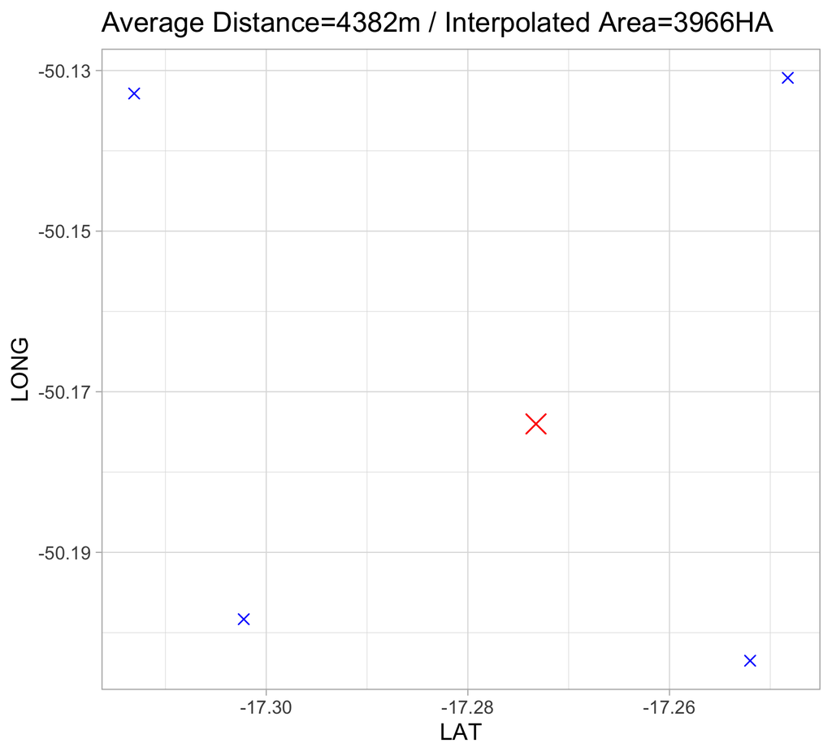

- Variable: Air Temperature
- Number of Neighbors: 4 Metos Weather Station (IMT300 and EcoD3)
- Av. Distance: 4382m
- Interpolation Area: 3966HA
- Starting Date: 2019-09-05 00:00:00
- End Date: 2020-09-01 14:00:00
- No of observations: 8328 (hourly data)  
  ### Descriptive Statistics

Let’s go ahead with the analytics. We want to get some descriptive statistics from the data so to understand what we have in hand:

| index | Averages |
| --- | --- |
| Verification_01205953 | 24.46 |
| Range | 2.78 |
| MAX | 25.93 |
| MIN | 23.14 |
| SD | 1.25 |
| Mean | 24.49 |

We can observe that within our area of interest of 3966HA, we have an average temperature over the period measured of 24.49ºC. However, this temperature is not a good representation for the entire field. We see an average standard deviation of 1.25ºC. This means, at any given moment, we have to expect that the ‘average spot’ within this field deviates 1.25ºC from the mean of the field temperature. The difference between the hottest and the coldest measurement is even bigger (of course!). In average over the period, the difference between the maximum and the minimum temperature is 2.78ºC. This is remarkable! Such differences are important for agronomic decisions. I because it justifies that we work with multiplie weather staitons in that area and it also gives weight to our at hand study.

### Interpolation Estimators

Let’s keep on then. We are now ready to run the following interpolation methods for estimating the temperatures at Point 0.

• Inverse Distance weighing with power 1

• Inverse Distance weighing with power 2

• Inverse Distance weighing with power 3

• Sample mean, i.e. we just use the average temperature of all 4 stations as an estimator

Remember that we do this for each of the 8328 hourly temperatures and without using the weather station from Point 0. Once we have this estimation, we then calculate the error for each hour by *subtracting the estimated values from the Verification Station* at Point 0. This error is is what interests us most, because it tells us how much we can trust into a given interpolaiton method.Here the results:

[figure not shown]

[figure not shown]

[figure not shown]

[figure not shown]